# Introduction to DEsiR

Kevin Healy

2016-09-02

```r
# check if you have devools and install if you do not
if(!require(devtools)) install.packages("devtools")

# check if you have mulTree and install if you do not using devtools
if(!require(mulTree)) devtools::install_github("TGuillerme/mulTree", ref = "master")
```

Following this you can then install directly from GitHub using the following:

```r
# Check if you have DEsiR and install from github if you do not
if(!require(DEsiR)) devtools::install_github("healyke/DEsiR", ref = "master")
```

Load the package

```r
# You could load mulTree if you want, but you do not need to as you can
# call is functions using e.g. mulTree::tree.bind as below.
#library(mulTree)
library(DEsiR)
```

## Read in the data

And load in the data

```r
#read in the data
DEsiR.data <- read.csv(file = system.file("extdata",
                                          "DEsiR_data.csv",
                                          package = "DEsiR"),
                       header = TRUE,
                       stringsAsFactors = FALSE)

# view the first 10 rows of the dataframe
head(DEsiR.data)
```

```
##             species     habitat taxonomic.class tissue diet.type
## 1 Rattus_norvegicus terrestrial        mammalia  liver herbivore
## 2 Rattus_norvegicus terrestrial        mammalia  liver carnivore
## 3 Rattus_norvegicus terrestrial        mammalia  liver  omnivore
## 4 Rattus_norvegicus terrestrial        mammalia  liver  omnivore
## 5 Rattus_norvegicus terrestrial        mammalia  blood herbivore
## 6 Rattus_norvegicus terrestrial        mammalia  blood carnivore
##   source.iso.13C source.iso.15N delta13C delta15N
## 1          -25.3            4.8      3.1      1.2
## 2          -16.2           12.3      3.1      0.6
## 3          -24.5            7.1      1.5      3.2
## 4          -16.7            7.4      2.2      3.0
## 5          -25.3            4.8      1.5      3.6
## 6          -16.2           12.3      0.7      3.7
```

```r
#read in the phylogenetic information
#first the mammal trees
mammal_trees <- ape::read.tree(system.file("extdata",
                                      "3firstFritzTrees.tre",
                                      package = "DEsiR"))
#then the bird trees
bird_trees   <- ape::read.tree(system.file("extdata",
                                      "3firstJetzTrees.tre",
                                      package = "DEsiR"))

#combine them together using the tree.bind function from the mulTree package
combined_trees <- mulTree::tree.bind(x = mammal_trees,
                                     y = bird_trees,
                                     sample = 2,
                                     root.age = 250)
```

In order to estimate a trophic enrichment factor for a new species we need to check that the species is already present in our phylogeny and check what data is available for the new species.

setTefEst checks for the presence of the following data: tissue type (“blood”, “claws”, “collagen”, “feather”, “hair”, “kidney”, “liver”, “milk”, “muscle”), habitat (“terrestrial”, “marine”), diet.type (“carnivore”, “herbivore”, “omnivore”, “pellet”), and the isotopic ratios of the food sources for carbon (source.iso.13C) and nitrogen (source.iso.15N).

```r
#####function that checks the data for some species we want to estimate TEF for
new.data.test <- setTefEst(species = "Meles_meles",
                             habitat = "terrestrial",
                             taxonomic.class = "mammalia",
                             tissue = "blood",
                             diet.type = "omnivore",
                             source.iso.13C = c(-24.1),
                             source.iso.15N = c(7.0),
                             tree = combined_trees)
```

```
## Meles_meles present in phylogeny
```

If the species is not in the phylogeny already, such as say the Komodo dragon (Varanus komodoensis), or we are missing values as donated by NA, say tissue type, we get warning messages to indicate what is missing from our data.

[output not shown]

[output not shown]

We now need to format the data by combining both the isotopic data already available within the package and the data from the new species and matching these species to the included phylogeny. We also include what isotope we want to estimate a trophic discrimination value for (either “carbon” or “nitrogen”).

```r
tdf_data_c <- tefMulClean(new.data = new.data.test,
                          data = DEsiR.data,
                          species.col.name = "species",
                          tree =
                          combined_trees,
                          taxonomic.class = "mammalia",
                          isotope = "carbon")
```

[output not shown]

We now have a mulTree class object, which is required by the imputation analysis. It contains the matched phylogenies, in this case two phylogenies

```r
tdf_data_c$phy
```

```
## 2 phylogenetic trees
```

and a dataset containing TDF and related data with the new species for which you want to estimate a trophic enrichment factor at the top with a NA for either delta13C or delta15N depending on isotope.

```r
head(tdf_data_c$data)
```

```
##                sp.col     habitat taxonomic.class tissue diet.type
## 1         Meles_meles terrestrial        mammalia  blood  omnivore
## 120 Rattus_norvegicus terrestrial        mammalia  liver herbivore
## 2   Rattus_norvegicus terrestrial        mammalia  liver carnivore
## 3   Rattus_norvegicus terrestrial        mammalia  liver  omnivore
## 4   Rattus_norvegicus terrestrial        mammalia  liver  omnivore
## 5   Rattus_norvegicus terrestrial        mammalia  blood herbivore
##     source.iso.13C delta13C            animal
## 1            -24.1       NA       Meles_meles
## 120          -25.3      3.1 Rattus_norvegicus
## 2            -16.2      3.1 Rattus_norvegicus
## 3            -24.5      1.5 Rattus_norvegicus
## 4            -16.7      2.2 Rattus_norvegicus
## 5            -25.3      1.5 Rattus_norvegicus
```

With the data formatted as a mulTree object we now need to set up the model. In this case we will run the full model to estimate delta13C with the fixed factors of source isotopic ratio, diet type and habitat type.

```r
formula.c <- delta13C ~ source.iso.13C + diet.type + habitat
```

and random terms that includes the “animal” term which is required to include phylogeny into the analysis, sp.col to allow multiple species entries into the analysis and account for variation within a species, and tissue type.

```r
random.terms = ~ animal + sp.col + tissue
```

```r
prior <- list(R = list(V = 1/4, nu=0.002),
              G = list(G1=list(V = 1/4, nu=0.002),
                       G2=list(V = 1/4, nu=0.002),
                       G3=list(V = 1/4, nu=0.002)))
```

```r
# nitt <- c(1200000)
# burnin <- c(200000)
# thin <- c(500)
# no.chains <- c(2)

# NB settings only for testing. need to change
nitt <- c(10)
burnin <- c(1)
thin <- c(1)
no.chains <- c(2)
```

We need to check that our MCMC chains are converging so we use the Gelman and Rubin diagnostic to check the convergence and also check that the estimated parameters have an effective sample size >1000.

```r
convergence =  c(1.1)
ESS = c(1000)
```

As the function exports the model output to avoid memory issues within R make sure you have set the working directory to somewhere appropriate.

```r
getwd()
```

```
## [1] "/Users/andrewjackson/Documents/Projects/DEsiR/vignettes"
```

```r
list.files()
```

```
##  [1] "Introduction-to-DEsiR.R"     "Introduction-to-DEsiR.Rmd"
##  [3] "Introduction-to-DEsiR.html"  "Introduction-to-DEsiR.pdf"
##  [5] "test_c_run-tree1_chain1.rda" "test_c_run-tree1_chain2.rda"
##  [7] "test_c_run-tree1_conv.rda"   "test_c_run-tree2_chain1.rda"
##  [9] "test_c_run-tree2_chain2.rda" "test_c_run-tree2_conv.rda"
```

```r
TDF_est.c <- tefMcmcglmm(mulTree.data = tdf_data_c,
                         formula = formula.c,
                         random.terms = random.terms,
                         prior = prior,
                         output = "test_c_run",
                         nitt = nitt,
                         thin = thin,
                         burnin = burnin,
                         no.chains = no.chains,
                         convergence =  convergence,
                         ESS = ESS)
```

```
## Output chain name "test_c_run" already exists!
## Press [enter] if you wish to overwrite the models or [esc] to cancel.
```

```
## Models will be overwritten...
```

```
##
## 2016-09-02 - 19:38:55: MCMCglmm performed on tree 1
## Convergence diagnosis:
## Effective sample size is > 1000: FALSE
## 9; 42.37562; 9; 9; 9; 9; 9; 9; 9; 9; 9; 9; 9; 9; 9; 9; 9; 2.171747; 2.287062; 9
## C1.Sol.(Intercept), C1.Sol.source.iso.13C, C1.Sol.diet.typeherbivore, C1.Sol.diet.typeomnivore, C1.Sol.diet.typepellet, C1.Sol.habitatterrestrial, C1.VCV.animal, C1.VCV.sp.col, C1.VCV.tissue, C1.VCV.units, C2.Sol.(Intercept), C2.Sol.source.iso.13C, C2.Sol.diet.typeherbivore, C2.Sol.diet.typeomniv…
## All levels converged < 1.1: FALSE
## 1.081334; 0.9284101; 3.450966; 1.172151; 1.606406; 1.054353; 17.93665; 1.814335
## Individual models saved as: test_c_run-tree1_chain*.rda
## Convergence diagnosis saved as: test_c_run-tree1_conv.rda
##
## 2016-09-02 - 19:38:56: MCMCglmm performed on tree 2
## Convergence diagnosis:
## Effective sample size is > 1000: FALSE
## 9; 1.703224; 9; 9; 16.78626; 9; 1.947472; 2.862925; 9; 9; 9; 9; 9; 9; 9; 9; 9; 2.287784; 9; 9
## C1.Sol.(Intercept), C1.Sol.source.iso.13C, C1.Sol.diet.typeherbivore, C1.Sol.diet.typeomnivore, C1.Sol.diet.typepellet, C1.Sol.habitatterrestrial, C1.VCV.animal, C1.VCV.sp.col, C1.VCV.tissue, C1.VCV.units, C2.Sol.(Intercept), C2.Sol.source.iso.13C, C2.Sol.diet.typeherbivore, C2.Sol.diet.typeomniv…
## All levels converged < 1.1: FALSE
## 7.333927; 4.097252; 0.9366509; 1.622404; 20.38587; 8.875057; 1.138735; 3.222737
## Individual models saved as: test_c_run-tree2_chain*.rda
## Convergence diagnosis saved as: test_c_run-tree2_conv.rda
##
## 2016-09-02 - 19:38:56: MCMCglmm successfully performed on 2 trees.
## Total execution time: 1.044563 secs.
## Use read.mulTree() to read the data as 'mulTree' data.
## Use summary.mulTree() and plot.mulTree() for plotting or summarizing the 'mulTree' data.
```

tefMcmcglmm now runs the selected amount of chains (no.chains) for each of the sampled phylogeny and exports the resulting MCMC chains to the working directory. Hence in this case we have run two chains for each of the two sampled trees so there should be four files in your working directory ending with something like run-tree1_chain2.rda.

```r
list.files()
```

```
##  [1] "Introduction-to-DEsiR.R"     "Introduction-to-DEsiR.Rmd"
##  [3] "Introduction-to-DEsiR.html"  "Introduction-to-DEsiR.pdf"
##  [5] "test_c_run-tree1_chain1.rda" "test_c_run-tree1_chain2.rda"
##  [7] "test_c_run-tree1_conv.rda"   "test_c_run-tree2_chain1.rda"
##  [9] "test_c_run-tree2_chain2.rda" "test_c_run-tree2_conv.rda"
```

These are the full MCMCglmm model outputs for each of the chains run and can be imported back into the R for full inspection if required using read.mulTree. Notice also the two other files ending with something simlar to run-tree2_conv. These give a discriotion on the convergance diagnostics of the chains for each tree. The results of these diagnostics for each tree are also printed in R after running tefMcmcglmm returing whether the Effective sample size exceded ESS for all estimated paramaters (with the number for each parameter given as a list), and whether al chains converged for each parameter.

All these models can be seperatly imported into R using read.mulTree(). However, since we are only intrested in the estimated TDF for our species tefMcmcglmm only imports the imputed posterior distribution of the estimated TDF for our species.

```r
names(TDF_est.c)
```

```
## [1] "tef_estimates" "tef_global"
```

```r
summary(TDF_est.c$tef_global)
```

```
##
## Iterations = 1:36
## Thinning interval = 1
## Number of chains = 1
## Sample size per chain = 36
##
## 1. Empirical mean and standard deviation for each variable,
##    plus standard error of the mean:
##
##           Mean             SD       Naive SE Time-series SE
##         2.5836         1.4806         0.2468         0.3697
##
## 2. Quantiles for each variable:
##
##     2.5%      25%      50%      75%    97.5%
## 0.007228 1.258342 2.704542 3.734434 4.946248
```

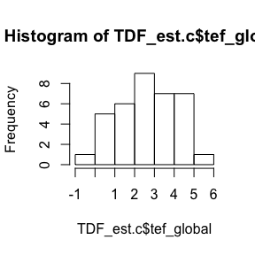

```r
hist(TDF_est.c$tef_global)
```